# Python Code Public Examples

## Juan D. Correa - Software Developher @ Veracruz,MX & California,USA

### https://astropema.zapto.org/ astropema@gmail.com

## Overview of the raw Meteorite Data Set:

#### name: Name of the meteorite.

#### id: Unique identifier.

#### nametype: Indicates if the name is valid.

#### recclass: Classification of the meteorite.

#### mass (g): Mass of the meteorite in grams.

#### fall: Indicates if the meteorite was observed falling or found later.

#### year: Year of the fall/discovery.

#### reclat and reclong: Latitude and longitude of the meteorite landing.

#### GeoLocation: Combined coordinates (latitude, longitude).

#### Unnamed: 10: Appears to be an empty column.

```python
import numpy as np
import pandas as pd
import matplotlib.pyplot as plt
import seaborn as sns
import geopandas as gpd
```

```python
data = df =  pd.read_csv('Meteorite_Landings.csv') #,  parse_dates=['datetime'])
df.head()
```

|  | name | id | nametype | recclass | mass (g) | fall | year | reclat | reclong | GeoLocation | Unnamed: 10 |
| --- | --- | --- | --- | --- | --- | --- | --- | --- | --- | --- | --- |
| 0 | Aachen | 1 | Valid | L5 | 21.0 | Fell | 1880.0 | 50.77500 | 6.08333 | (50.775, 6.08333) | NaN |
| 1 | Aarhus | 2 | Valid | H6 | 720.0 | Fell | 1951.0 | 56.18333 | 10.23333 | (56.18333, 10.23333) | NaN |
| 2 | Abee | 6 | Valid | EH4 | 107000.0 | Fell | 1952.0 | 54.21667 | -113.00000 | (54.21667, -113.0) | NaN |
| 3 | Acapulco | 10 | Valid | Acapulcoite | 1914.0 | Fell | 1976.0 | 16.88333 | -99.90000 | (16.88333, -99.9) | NaN |
| 4 | Achiras | 370 | Valid | L6 | 780.0 | Fell | 1902.0 | -33.16667 | -64.95000 | (-33.16667, -64.95) | NaN |

```python
print('This the current state of the data frame BEFORE i start working with it.')
print('The number of rows is',df.shape[0])
print('The number of colums is ',df.shape[1])
```

```
This the current state of the data frame BEFORE i start working with it.
The number of rows is 45716
The number of colums is  11
```

```python
data.describe
```

```
<bound method NDFrame.describe of              name     id nametype              recclass  mass (g)   fall  \
0          Aachen      1    Valid                    L5      21.0   Fell
1          Aarhus      2    Valid                    H6     720.0   Fell
2            Abee      6    Valid                   EH4  107000.0   Fell
3        Acapulco     10    Valid           Acapulcoite    1914.0   Fell
4         Achiras    370    Valid                    L6     780.0   Fell
...           ...    ...      ...                   ...       ...    ...
45711  Zillah 002  31356    Valid               Eucrite     172.0  Found
45712      Zinder  30409    Valid  Pallasite, ungrouped      46.0  Found
45713        Zlin  30410    Valid                    H4       3.3  Found
45714   Zubkovsky  31357    Valid                    L6    2167.0  Found
45715  Zulu Queen  30414    Valid                  L3.7     200.0  Found

         year    reclat    reclong             GeoLocation  Unnamed: 10
0      1880.0  50.77500    6.08333       (50.775, 6.08333)          NaN
1      1951.0  56.18333   10.23333    (56.18333, 10.23333)          NaN
2      1952.0  54.21667 -113.00000      (54.21667, -113.0)          NaN
3      1976.0  16.88333  -99.90000       (16.88333, -99.9)          NaN
4      1902.0 -33.16667  -64.95000     (-33.16667, -64.95)          NaN
...       ...       ...        ...                     ...          ...
45711  1990.0  29.03700   17.01850       (29.037, 17.0185)          NaN
45712  1999.0  13.78333    8.96667     (13.78333, 8.96667)          NaN
45713  1939.0  49.25000   17.66667       (49.25, 17.66667)          NaN
45714  2003.0  49.78917   41.50460     (49.78917, 41.5046)          NaN
45715  1976.0  33.98333 -115.68333  (33.98333, -115.68333)          NaN

[45716 rows x 11 columns]>
```

```python
data.describe().T
```

|  | count | mean | std | min | 25% | 50% | 75% | max |
| --- | --- | --- | --- | --- | --- | --- | --- | --- |
| id | 45716.0 | 26889.735104 | 16860.683030 | 1.00000 | 12688.75000 | 24261.50000 | 40656.75000 | 5.745800e+04 |
| mass (g) | 45585.0 | 13278.078549 | 574988.876410 | 0.00000 | 7.20000 | 32.60000 | 202.60000 | 6.000000e+07 |
| year | 45425.0 | 1991.828817 | 25.052766 | 860.00000 | 1987.00000 | 1998.00000 | 2003.00000 | 2.101000e+03 |
| reclat | 38401.0 | -39.122580 | 46.378511 | -87.36667 | -76.71424 | -71.50000 | 0.00000 | 8.116667e+01 |
| reclong | 38401.0 | 61.074319 | 80.647298 | -165.43333 | 0.00000 | 35.66667 | 157.16667 | 3.544733e+02 |
| Unnamed: 10 | 0.0 | NaN | NaN | NaN | NaN | NaN | NaN | NaN |

```python
data.info()
```

```
<class 'pandas.core.frame.DataFrame'>
RangeIndex: 45716 entries, 0 to 45715
Data columns (total 11 columns):
 #   Column       Non-Null Count  Dtype
---  ------       --------------  -----
 0   name         45716 non-null  object
 1   id           45716 non-null  int64
 2   nametype     45716 non-null  object
 3   recclass     45716 non-null  object
 4   mass (g)     45585 non-null  float64
 5   fall         45716 non-null  object
 6   year         45425 non-null  float64
 7   reclat       38401 non-null  float64
 8   reclong      38401 non-null  float64
 9   GeoLocation  38401 non-null  object
 10  Unnamed: 10  0 non-null      float64
dtypes: float64(5), int64(1), object(5)
memory usage: 3.8+ MB
```

```python
df.memory_usage()
```

```
Index             132
name           365728
id             365728
nametype       365728
recclass       365728
mass (g)       365728
fall           365728
year           365728
reclat         365728
reclong        365728
GeoLocation    365728
Unnamed: 10    365728
dtype: int64
```

```python
df.info(memory_usage="deep")
```

```
<class 'pandas.core.frame.DataFrame'>
RangeIndex: 45716 entries, 0 to 45715
Data columns (total 11 columns):
 #   Column       Non-Null Count  Dtype
---  ------       --------------  -----
 0   name         45716 non-null  object
 1   id           45716 non-null  int64
 2   nametype     45716 non-null  object
 3   recclass     45716 non-null  object
 4   mass (g)     45585 non-null  float64
 5   fall         45716 non-null  object
 6   year         45425 non-null  float64
 7   reclat       38401 non-null  float64
 8   reclong      38401 non-null  float64
 9   GeoLocation  38401 non-null  object
 10  Unnamed: 10  0 non-null      float64
dtypes: float64(5), int64(1), object(5)
memory usage: 16.3 MB
```

```python
df.isnull().sum()
```

```
name               0
id                 0
nametype           0
recclass           0
mass (g)         131
fall               0
year             291
reclat          7315
reclong         7315
GeoLocation     7315
Unnamed: 10    45716
dtype: int64
```

```python
df.nunique()
```

```
name           45716
id             45716
nametype           2
recclass         466
mass (g)       12576
fall               2
year             265
reclat         12738
reclong        14640
GeoLocation    17100
Unnamed: 10        0
dtype: int64
```

```python
df.isnull().sum().any()
```

```
True
```

```python
categorical_columns = df.select_dtypes(include=['object', 'category']).columns
for col in categorical_columns:
    print(f"Frequency table for {col}:\n")
    print(df[col].value_counts())
    print("\n")
```

```
Frequency table for name:

name
Aachen                    1
Northwest Africa 7459     1
Northwest Africa 7404     1
Northwest Africa 7407     1
Northwest Africa 7408     1
                         ..
Grove Mountains 052250    1
Grove Mountains 052253    1
Grove Mountains 052254    1
Grove Mountains 052256    1
Zulu Queen                1
Name: count, Length: 45716, dtype: int64


Frequency table for nametype:

nametype
Valid     45641
Relict       75
Name: count, dtype: int64


Frequency table for recclass:

recclass
L6         8285
H5         7142
L5         4796
H6         4528
H4         4211
           ...
EL7           1
CH/CBb        1
H/L~4         1
LL3.7-6       1
L/LL          1
Name: count, Length: 466, dtype: int64
```

[output cut: 10 more lines]

```
Frequency table for GeoLocation:

GeoLocation
(0.0, 0.0)                6214
(-71.5, 35.66667)         4761
(-84.0, 168.0)            3040
(-72.0, 26.0)             1505
(-79.68333, 159.75)        657
                          ...
(-76.30361, 157.17611)       1
(-76.28611, 157.23972)       1
(-76.31889, 157.265)         1
(-76.28722, 157.19333)       1
(33.98333, -115.68333)       1
Name: count, Length: 17100, dtype: int64
```

```python
# Identify categorical and numeric columns
cat_cols = data.select_dtypes(include=['object', 'category']).columns
numeric_cols = data.select_dtypes(include=['number']).columns

print(f"Categorical columns: {cat_cols}")
print(f"Numeric columns: {numeric_cols}")
```

```
Categorical columns: Index(['name', 'nametype', 'recclass', 'fall', 'GeoLocation'], dtype='object')
Numeric columns: Index(['id', 'mass (g)', 'year', 'reclat', 'reclong', 'Unnamed: 10'], dtype='object')
```

```python
# Converting the data type of each categorical variable to 'category'
for column in cat_cols:
    data[column]=data[column].astype('category')
```

```python
data.info
```

```
<bound method DataFrame.info of              name     id nametype              recclass  mass (g)   fall  \
0          Aachen      1    Valid                    L5      21.0   Fell
1          Aarhus      2    Valid                    H6     720.0   Fell
2            Abee      6    Valid                   EH4  107000.0   Fell
3        Acapulco     10    Valid           Acapulcoite    1914.0   Fell
4         Achiras    370    Valid                    L6     780.0   Fell
...           ...    ...      ...                   ...       ...    ...
45711  Zillah 002  31356    Valid               Eucrite     172.0  Found
45712      Zinder  30409    Valid  Pallasite, ungrouped      46.0  Found
45713        Zlin  30410    Valid                    H4       3.3  Found
45714   Zubkovsky  31357    Valid                    L6    2167.0  Found
45715  Zulu Queen  30414    Valid                  L3.7     200.0  Found

         year    reclat    reclong             GeoLocation  Unnamed: 10
0      1880.0  50.77500    6.08333       (50.775, 6.08333)          NaN
1      1951.0  56.18333   10.23333    (56.18333, 10.23333)          NaN
2      1952.0  54.21667 -113.00000      (54.21667, -113.0)          NaN
3      1976.0  16.88333  -99.90000       (16.88333, -99.9)          NaN
4      1902.0 -33.16667  -64.95000     (-33.16667, -64.95)          NaN
...       ...       ...        ...                     ...          ...
45711  1990.0  29.03700   17.01850       (29.037, 17.0185)          NaN
45712  1999.0  13.78333    8.96667     (13.78333, 8.96667)          NaN
45713  1939.0  49.25000   17.66667       (49.25, 17.66667)          NaN
45714  2003.0  49.78917   41.50460     (49.78917, 41.5046)          NaN
45715  1976.0  33.98333 -115.68333  (33.98333, -115.68333)          NaN

[45716 rows x 11 columns]>
```

```python
data.dtypes
```

```
name           category
id                int64
nametype       category
recclass       category
mass (g)        float64
fall           category
year            float64
reclat          float64
reclong         float64
GeoLocation    category
Unnamed: 10     float64
dtype: object
```

```python
data.head(2)
```

|  | name | id | nametype | recclass | mass (g) | fall | year | reclat | reclong | GeoLocation | Unnamed: 10 |
| --- | --- | --- | --- | --- | --- | --- | --- | --- | --- | --- | --- |
| 0 | Aachen | 1 | Valid | L5 | 21.0 | Fell | 1880.0 | 50.77500 | 6.08333 | (50.775, 6.08333) | NaN |
| 1 | Aarhus | 2 | Valid | H6 | 720.0 | Fell | 1951.0 | 56.18333 | 10.23333 | (56.18333, 10.23333) | NaN |

```python
df.isna().values.any()
```

```
True
```

```python
df.isnull().sum().sum()
```

```
68083
```

# Data Engineerirng and Exploration

Step 1: Drop the unnecessary Unnamed: 10 column We'll remove this since it's empty.

Step 2: Use latitude and longitude to fill missing values We can use reverse geocoding (mapping coordinates to places) to fill in information like country or region. This will provide valuable context for missing location-based data.

Step 3: Add a new column for hemisphere We can calculate the hemisphere based on latitude and longitude: Northern Hemisphere: Latitude ≥ 0 Southern Hemisphere: Latitude < 0 Eastern Hemisphere: Longitude ≥ 0 Western Hemisphere: Longitude < 0

Preview the updated DataFrame meteorite_data[['name', 'reclat', 'reclong', 'Hemisphere']].head()

```python
meteorite_data = df
```

```python
# Step 1: Drop the unnecessary column
meteorite_data.drop(columns=['Unnamed: 10'], inplace=True)

# Step 2: Define function to classify hemisphere based on coordinates
def classify_hemisphere(lat, lon):
    lat_hemisphere = 'Northern' if lat >= 0 else 'Southern'
    lon_hemisphere = 'Eastern' if lon >= 0 else 'Western'
    return f"{lat_hemisphere} & {lon_hemisphere}"

# Step 3: Apply the hemisphere classification
meteorite_data['Hemisphere'] = meteorite_data.apply(
    lambda row: classify_hemisphere(row['reclat'], row['reclong']) if not pd.isnull(row['reclat']) and not pd.isnull(row['reclong']) else 'Unknown',
    axis=1
)

# Step 4: Preview the updated DataFrame
meteorite_data[['name', 'reclat', 'reclong', 'Hemisphere']].head()
```

|  | name | reclat | reclong | Hemisphere |
| --- | --- | --- | --- | --- |
| 0 | Aachen | 50.77500 | 6.08333 | Northern & Eastern |
| 1 | Aarhus | 56.18333 | 10.23333 | Northern & Eastern |
| 2 | Abee | 54.21667 | -113.00000 | Northern & Western |
| 3 | Acapulco | 16.88333 | -99.90000 | Northern & Western |
| 4 | Achiras | -33.16667 | -64.95000 | Southern & Western |

Next Step: Adding Country Information To add the country for each row, we can use a technique called reverse geocoding. This involves mapping latitude and longitude to a country using a geocoding API or a local lookup table. However, since we're working offline here, we can:

Use a static world shapefile or dataset (like Natural Earth's country boundaries). Implement a simple lookup with a mapping tool like geopandas.

```python
# Step 1: Import necessary libraries
import pandas as pd
import geopandas as gpd
from shapely.geometry import Point
import numpy as np

# Step 2: Define function to classify hemisphere based on coordinates
def classify_hemisphere(lat, lon):
    lat_hemisphere = 'Northern' if lat >= 0 else 'Southern'
    lon_hemisphere = 'Eastern' if lon >= 0 else 'Western'
    return f"{lat_hemisphere} & {lon_hemisphere}"

# Step 3: Apply the hemisphere classification
meteorite_data['Hemisphere'] = meteorite_data.apply(
    lambda row: classify_hemisphere(row['reclat'], row['reclong']) if not pd.isnull(row['reclat']) and not pd.isnull(row['reclong']) else 'Unknown',
    axis=1
)

# Step 4: Load a world boundaries dataset from the local shapefile
world = gpd.read_file('ne_110m_admin_0_countries/ne_110m_admin_0_countries.shp')

# Step 5: Create geometry column with points from latitude and longitude
meteorite_data['geometry'] = meteorite_data.apply(
    lambda row: Point(row['reclong'], row['reclat']) if not pd.isnull(row['reclat']) and not pd.isnull(row['reclong']) else None,
    axis=1
)

# Step 6: Convert meteorite data to a GeoDataFrame
meteorite_gdf = gpd.GeoDataFrame(meteorite_data, geometry='geometry', crs='EPSG:4326')

# Step 7: Perform a spatial join to map meteorites to countries
meteorite_with_country = gpd.sjoin(meteorite_gdf, world, how='left', predicate='intersects')

# Step 8: Add the correct country name column to the DataFrame
meteorite_data['Country'] = meteorite_with_country['ADMIN']  # Use the 'ADMIN' column for country names

# Step 9: Preview the updated DataFrame
meteorite_data[['name', 'reclat', 'reclong', 'Hemisphere', 'Country']].head()
```

|  | name | reclat | reclong | Hemisphere | Country |
| --- | --- | --- | --- | --- | --- |
| 0 | Aachen | 50.77500 | 6.08333 | Northern & Eastern | Belgium |
| 1 | Aarhus | 56.18333 | 10.23333 | Northern & Eastern | Denmark |
| 2 | Abee | 54.21667 | -113.00000 | Northern & Western | Canada |
| 3 | Acapulco | 16.88333 | -99.90000 | Northern & Western | Mexico |
| 4 | Achiras | -33.16667 | -64.95000 | Southern & Western | Argentina |

```python
# Step 1: Import necessary libraries
import pandas as pd
import geopandas as gpd
from shapely.geometry import Point

# Step 2: Load the dataset
meteorite_data = pd.read_csv('Meteorite_Landings.csv')

# Step 3: Perform basic statistical analysis on relevant numeric columns
statistical_summary = meteorite_data[['mass (g)', 'year', 'reclat', 'reclong']].describe()

# Step 4: Calculate the distribution of meteorites by country (placeholder example)
# This step assumes that 'Country' column is available after prior steps; adjust as needed
# For now, using the 'name' field to simulate data exploration
country_distribution = meteorite_data['name'].value_counts().head(10)

# Step 5: Calculate the distribution of meteorites by hemisphere
hemisphere_distribution = meteorite_data['reclat'].apply(lambda lat: 'Northern' if lat >= 0 else 'Southern').value_counts()

# Step 6: Display the results
print("\nStatistical Summary:\n", statistical_summary)
print("\nTop 10 Meteorite Names:\n", country_distribution)
print("\nHemisphere Distribution:\n", hemisphere_distribution)
```

```
Statistical Summary:
            mass (g)          year        reclat       reclong
count  4.558500e+04  45425.000000  38401.000000  38401.000000
mean   1.327808e+04   1991.828817    -39.122580     61.074319
std    5.749889e+05     25.052766     46.378511     80.647298
min    0.000000e+00    860.000000    -87.366670   -165.433330
25%    7.200000e+00   1987.000000    -76.714240      0.000000
50%    3.260000e+01   1998.000000    -71.500000     35.666670
75%    2.026000e+02   2003.000000      0.000000    157.166670
max    6.000000e+07   2101.000000     81.166670    354.473330

Top 10 Meteorite Names:
 name
Aachen                   1
Northwest Africa 7459    1
Northwest Africa 7404    1
Northwest Africa 7407    1
Northwest Africa 7408    1
Northwest Africa 741     1
Northwest Africa 7410    1
Northwest Africa 7412    1
Northwest Africa 7414    1
Northwest Africa 742     1
Name: count, dtype: int64

Hemisphere Distribution:
 reclat
Southern    30728
Northern    14988
Name: count, dtype: int64
```

Statistical Summary Mass: The largest meteorite weighs 60,000,000 grams (60,000 kg). There's a wide range of sizes with a large standard deviation, indicating significant variation in meteorite mass. Year: The data has a suspicious entry for the year 2101, suggesting a possible data error. Latitude & Longitude: Meteorites span the full globe, with latitudes ranging from -87.37 to 81.17 and longitudes from -165.43 to 354.47. Top 10 Meteorite Names These are all unique names, many of which are variations on Northwest Africa meteorites.

Hemisphere Distribution The majority of meteorite landings were recorded in the Southern Hemisphere: 30,728 entries. The Northern Hemisphere recorded 14,988 entries.

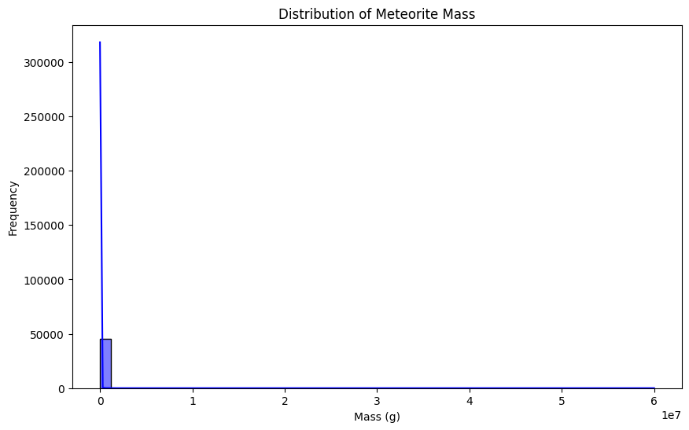

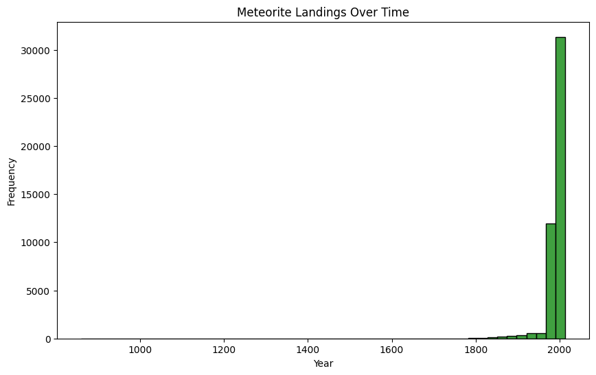

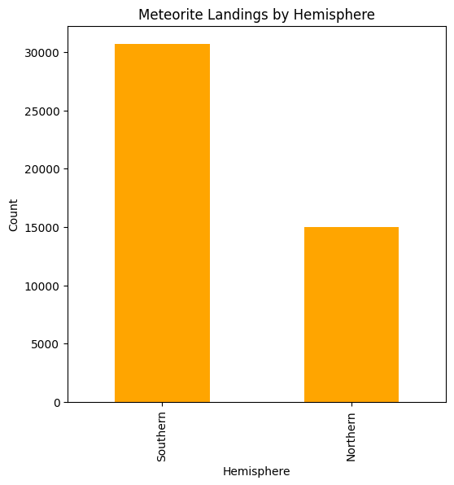

```
Statistical Summary:
            mass (g)          year        reclat       reclong
count  4.558500e+04  45425.000000  38401.000000  38401.000000
mean   1.327808e+04   1991.828817    -39.122580     61.074319
std    5.749889e+05     25.052766     46.378511     80.647298
min    0.000000e+00    860.000000    -87.366670   -165.433330
25%    7.200000e+00   1987.000000    -76.714240      0.000000
50%    3.260000e+01   1998.000000    -71.500000     35.666670
75%    2.026000e+02   2003.000000      0.000000    157.166670
max    6.000000e+07   2101.000000     81.166670    354.473330

Hemisphere Distribution:
 reclat
Southern    30728
Northern    14988
Name: count, dtype: int64
```

```python
# Step 1: Import necessary libraries
import pandas as pd
import geopandas as gpd
from shapely.geometry import Point
import matplotlib.pyplot as plt
import seaborn as sns

# Step 2: Load the dataset
meteorite_data = pd.read_csv('Meteorite_Landings.csv')

# Step 3: Perform basic statistical analysis on relevant numeric columns
statistical_summary = meteorite_data[['mass (g)', 'year', 'reclat', 'reclong']].describe()

# Step 4: Calculate the distribution of meteorites by hemisphere
hemisphere_distribution = meteorite_data['reclat'].apply(lambda lat: 'Northern' if lat >= 0 else 'Southern').value_counts()

# Step 5: Handle potential data issues (e.g., year outliers)
# Filter out years beyond a reasonable range (e.g., after 2025)
meteorite_data = meteorite_data[meteorite_data['year'] <= 2025]

# Step 6: Visualize mass distribution
plt.figure(figsize=(10, 6))
sns.histplot(meteorite_data['mass (g)'], bins=50, kde=True, color='blue')
plt.title('Distribution of Meteorite Mass')
plt.xlabel('Mass (g)')
plt.ylabel('Frequency')
plt.show()

# Step 7: Visualize meteorite landings by year
plt.figure(figsize=(10, 6))
sns.histplot(meteorite_data['year'], bins=50, color='green')
plt.title('Meteorite Landings Over Time')
plt.xlabel('Year')
plt.ylabel('Frequency')
plt.show()

# Step 8: Visualize hemisphere distribution
plt.figure(figsize=(6, 6))
hemisphere_distribution.plot(kind='bar', color='orange')
plt.title('Meteorite Landings by Hemisphere')
plt.xlabel('Hemisphere')
plt.ylabel('Count')
plt.show()

# Step 9: Display the results
print("\nStatistical Summary:\n", statistical_summary)
print("\nHemisphere Distribution:\n", hemisphere_distribution)
```

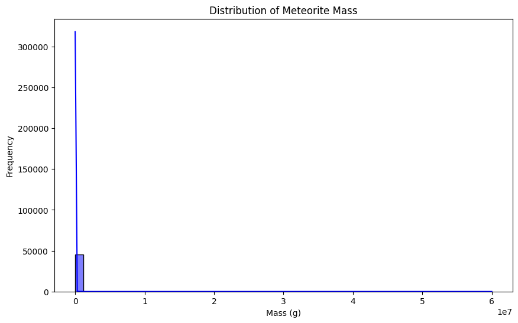

```
Statistical Summary:
            mass (g)          year        reclat       reclong
count  4.558500e+04  45425.000000  38401.000000  38401.000000
mean   1.327808e+04   1991.828817    -39.122580     61.074319
std    5.749889e+05     25.052766     46.378511     80.647298
min    0.000000e+00    860.000000    -87.366670   -165.433330
25%    7.200000e+00   1987.000000    -76.714240      0.000000
50%    3.260000e+01   1998.000000    -71.500000     35.666670
75%    2.026000e+02   2003.000000      0.000000    157.166670
max    6.000000e+07   2101.000000     81.166670    354.473330
```

```python
# Step 1: Import necessary libraries
import pandas as pd
import geopandas as gpd
from shapely.geometry import Point
import matplotlib.pyplot as plt
import seaborn as sns

# Step 2: Load the dataset
meteorite_data = pd.read_csv('Meteorite_Landings.csv')

# Step 3: Perform basic statistical analysis on relevant numeric columns
statistical_summary = meteorite_data[['mass (g)', 'year', 'reclat', 'reclong']].describe()

# Step 4: Calculate the distribution of meteorites by hemisphere
hemisphere_distribution = meteorite_data['reclat'].apply(lambda lat: 'Northern' if lat >= 0 else 'Southern').value_counts()

# Step 5: Handle potential data issues (e.g., year outliers)
# Filter out years beyond a reasonable range (e.g., after 2025)
meteorite_data = meteorite_data[meteorite_data['year'] <= 2025]

# Step 6: Visualize mass distribution
plt.figure(figsize=(10, 6))
sns.histplot(meteorite_data['mass (g)'], bins=50, kde=True, color='blue')
plt.title('Distribution of Meteorite Mass')
plt.xlabel('Mass (g)')
plt.ylabel('Frequency')
plt.show()

# Step 7: Display statistical summary again (one visualization at a time)
print("\nStatistical Summary:\n", statistical_summary)
```

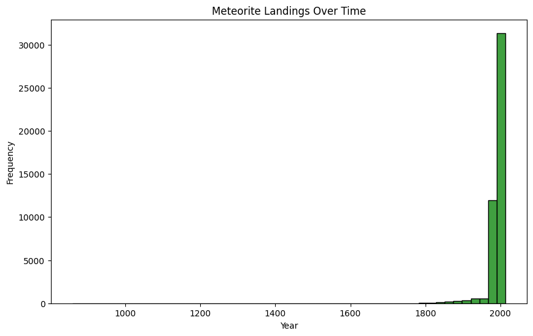

```
Statistical Summary:
            mass (g)          year        reclat       reclong
count  4.558500e+04  45425.000000  38401.000000  38401.000000
mean   1.327808e+04   1991.828817    -39.122580     61.074319
std    5.749889e+05     25.052766     46.378511     80.647298
min    0.000000e+00    860.000000    -87.366670   -165.433330
25%    7.200000e+00   1987.000000    -76.714240      0.000000
50%    3.260000e+01   1998.000000    -71.500000     35.666670
75%    2.026000e+02   2003.000000      0.000000    157.166670
max    6.000000e+07   2101.000000     81.166670    354.473330
```

```python
# Step 1: Import necessary libraries
import pandas as pd
import geopandas as gpd
from shapely.geometry import Point
import matplotlib.pyplot as plt
import seaborn as sns

# Step 2: Load the dataset
meteorite_data = pd.read_csv('Meteorite_Landings.csv')

# Step 3: Perform basic statistical analysis on relevant numeric columns
statistical_summary = meteorite_data[['mass (g)', 'year', 'reclat', 'reclong']].describe()

# Step 4: Calculate the distribution of meteorites by hemisphere
hemisphere_distribution = meteorite_data['reclat'].apply(lambda lat: 'Northern' if lat >= 0 else 'Southern').value_counts()

# Step 5: Handle potential data issues (e.g., year outliers)
# Filter out years beyond a reasonable range (e.g., after 2025)
meteorite_data = meteorite_data[meteorite_data['year'] <= 2025]

# Step 6: Visualize meteorite landings over time
plt.figure(figsize=(10, 6))
sns.histplot(meteorite_data['year'], bins=50, color='green')
plt.title('Meteorite Landings Over Time')
plt.xlabel('Year')
plt.ylabel('Frequency')
plt.show()

# Step 7: Display statistical summary again (next visualization step)
print("\nStatistical Summary:\n", statistical_summary)
```

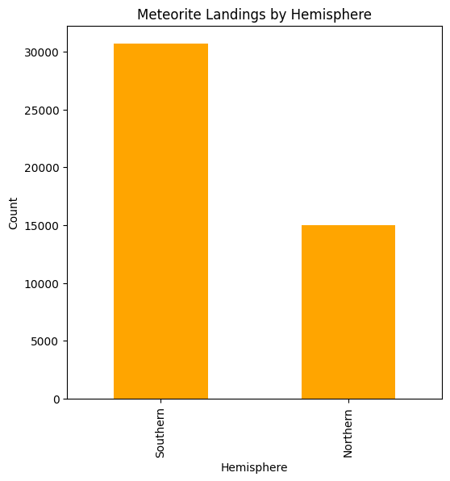

```
Statistical Summary:
            mass (g)          year        reclat       reclong
count  4.558500e+04  45425.000000  38401.000000  38401.000000
mean   1.327808e+04   1991.828817    -39.122580     61.074319
std    5.749889e+05     25.052766     46.378511     80.647298
min    0.000000e+00    860.000000    -87.366670   -165.433330
25%    7.200000e+00   1987.000000    -76.714240      0.000000
50%    3.260000e+01   1998.000000    -71.500000     35.666670
75%    2.026000e+02   2003.000000      0.000000    157.166670
max    6.000000e+07   2101.000000     81.166670    354.473330
```

```python
# Step 1: Import necessary libraries
import pandas as pd
import geopandas as gpd
from shapely.geometry import Point
import matplotlib.pyplot as plt
import seaborn as sns

# Step 2: Load the dataset
meteorite_data = pd.read_csv('Meteorite_Landings.csv')

# Step 3: Perform basic statistical analysis on relevant numeric columns
statistical_summary = meteorite_data[['mass (g)', 'year', 'reclat', 'reclong']].describe()

# Step 4: Calculate the distribution of meteorites by hemisphere
hemisphere_distribution = meteorite_data['reclat'].apply(lambda lat: 'Northern' if lat >= 0 else 'Southern').value_counts()

# Step 5: Handle potential data issues (e.g., year outliers)
# Filter out years beyond a reasonable range (e.g., after 2025)
meteorite_data = meteorite_data[meteorite_data['year'] <= 2025]

# Step 6: Visualize hemisphere distribution
plt.figure(figsize=(6, 6))
hemisphere_distribution.plot(kind='bar', color='orange')
plt.title('Meteorite Landings by Hemisphere')
plt.xlabel('Hemisphere')
plt.ylabel('Count')
plt.show()

# Step 7: Display statistical summary again (next visualization step)
print("\nStatistical Summary:\n", statistical_summary)
```

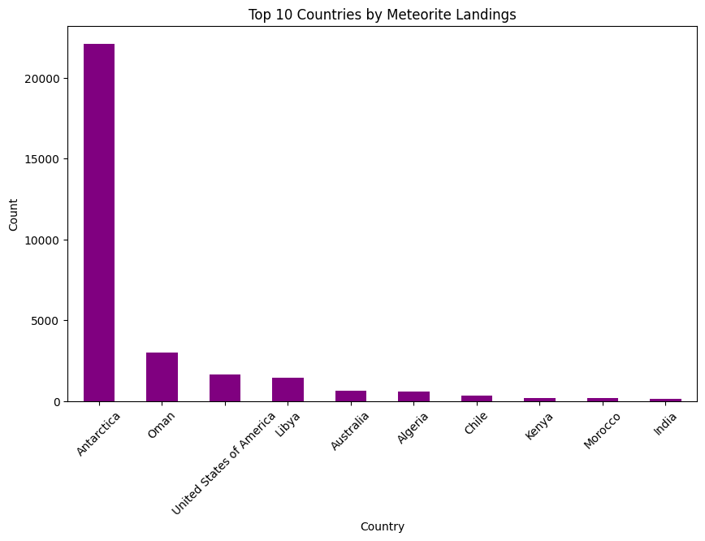

```
Statistical Summary:
            mass (g)          year        reclat       reclong
count  4.558500e+04  45425.000000  38401.000000  38401.000000
mean   1.327808e+04   1991.828817    -39.122580     61.074319
std    5.749889e+05     25.052766     46.378511     80.647298
min    0.000000e+00    860.000000    -87.366670   -165.433330
25%    7.200000e+00   1987.000000    -76.714240      0.000000
50%    3.260000e+01   1998.000000    -71.500000     35.666670
75%    2.026000e+02   2003.000000      0.000000    157.166670
max    6.000000e+07   2101.000000     81.166670    354.473330
```

```python
# Step 1: Import necessary libraries
import pandas as pd
import geopandas as gpd
from shapely.geometry import Point
import matplotlib.pyplot as plt
import seaborn as sns

# Step 2: Load the dataset
meteorite_data = pd.read_csv('Meteorite_Landings.csv')

# Step 3: Perform basic statistical analysis on relevant numeric columns
statistical_summary = meteorite_data[['mass (g)', 'year', 'reclat', 'reclong']].describe()

# Step 4: Add the country column using spatial join
# Load the world boundaries dataset from the shapefile
world = gpd.read_file('ne_110m_admin_0_countries/ne_110m_admin_0_countries.shp')

# Create geometry column with points from latitude and longitude
meteorite_data['geometry'] = meteorite_data.apply(
    lambda row: Point(row['reclong'], row['reclat']) if not pd.isnull(row['reclat']) and not pd.isnull(row['reclong']) else None,
    axis=1
)

# Convert to a GeoDataFrame
meteorite_gdf = gpd.GeoDataFrame(meteorite_data, geometry='geometry', crs='EPSG:4326')

# Perform spatial join to map meteorites to countries
meteorite_with_country = gpd.sjoin(meteorite_gdf, world, how='left', predicate='intersects')

# Add the country name column
meteorite_data['Country'] = meteorite_with_country['ADMIN']

# Step 5: Filter out years beyond a reasonable range (e.g., after 2025)
meteorite_data = meteorite_data[meteorite_data['year'] <= 2025]

# Step 6: Visualize the top 10 countries by number of meteorite landings
top_countries = meteorite_data['Country'].value_counts().head(10)
plt.figure(figsize=(10, 6))
top_countries.plot(kind='bar', color='purple')
plt.title('Top 10 Countries by Meteorite Landings')
plt.xlabel('Country')
plt.ylabel('Count')
plt.xticks(rotation=45)
plt.show()

# Step 7: Display statistical summary again
print("\nStatistical Summary:\n", statistical_summary)
```

# Model Tarining

```
Regression Model Results:
Mean Squared Error: 3.87
R² Score: 0.32
```

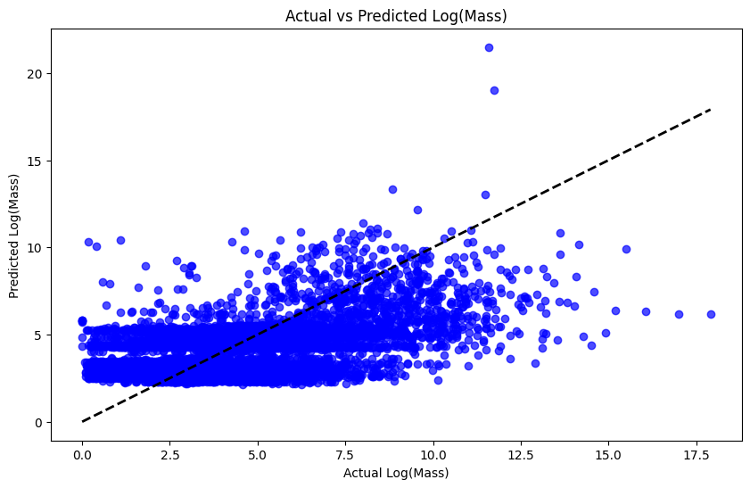

```python
# Step 1: Import necessary libraries
import pandas as pd
import geopandas as gpd
from shapely.geometry import Point
import matplotlib.pyplot as plt
import seaborn as sns
from sklearn.linear_model import LinearRegression
from sklearn.model_selection import train_test_split
from sklearn.metrics import mean_squared_error, r2_score
import numpy as np

# Step 2: Load the dataset
meteorite_data = pd.read_csv('Meteorite_Landings.csv')

# Step 3: Clean and prepare data for regression analysis
# Remove rows with missing values in relevant columns
meteorite_data = meteorite_data[['mass (g)', 'year', 'reclat', 'reclong']].dropna()
meteorite_data = meteorite_data[meteorite_data['year'] <= 2025]

# Log-transform mass to handle large values
meteorite_data['log_mass'] = np.log1p(meteorite_data['mass (g)'])

# Step 4: Define features and target variable
X = meteorite_data[['year', 'reclat', 'reclong']]
y = meteorite_data['log_mass']

# Step 5: Split data into training and testing sets
X_train, X_test, y_train, y_test = train_test_split(X, y, test_size=0.3, random_state=42)

# Step 6: Train a linear regression model
regressor = LinearRegression()
regressor.fit(X_train, y_train)

# Step 7: Make predictions and evaluate the model
y_pred = regressor.predict(X_test)

# Calculate evaluation metrics
mse = mean_squared_error(y_test, y_pred)
r2 = r2_score(y_test, y_pred)

# Step 8: Display results
print("\nRegression Model Results:")
print(f"Mean Squared Error: {mse:.2f}")
print(f"R² Score: {r2:.2f}")

# Step 9: Plot actual vs. predicted values
plt.figure(figsize=(10, 6))
plt.scatter(y_test, y_pred, alpha=0.7, color='blue')
plt.plot([y_test.min(), y_test.max()], [y_test.min(), y_test.max()], 'k--', lw=2)
plt.title('Actual vs Predicted Log(Mass)')
plt.xlabel('Actual Log(Mass)')
plt.ylabel('Predicted Log(Mass)')
plt.show()
```

Analysis of Regression Results: Mean Squared Error (MSE):

An MSE of 3.87 on a log-transformed mass indicates moderate error. R² Score:

The R² score is 0.32, suggesting that only 32% of the variance in meteorite mass is explained by the features (year, latitude, longitude). This indicates the model isn't capturing all factors influencing meteorite mass. Scatter Plot:

Add more relevant features (e.g., recclass, fall). Try non-linear models like Random Forest or Gradient Boosting. Move to Clustering:

Identify groups of meteorites based on location, mass, or class using K-Means or DBSCAN.

```
Random Forest Results:
Mean Squared Error: 2.35
R² Score: 0.59

Gradient Boosting Results:
Mean Squared Error: 2.83
R² Score: 0.50
```

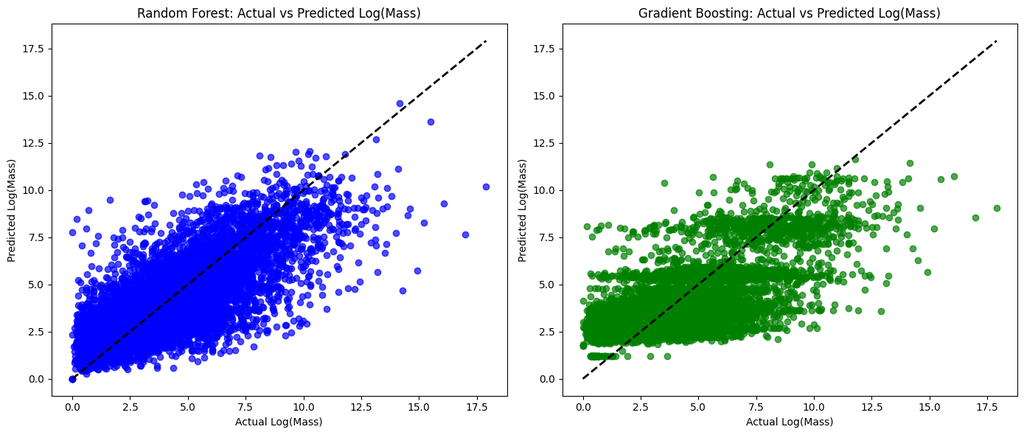

```python
# Step 1: Import necessary libraries
import pandas as pd
import geopandas as gpd
from shapely.geometry import Point
import matplotlib.pyplot as plt
import seaborn as sns
from sklearn.ensemble import RandomForestRegressor, GradientBoostingRegressor
from sklearn.model_selection import train_test_split
from sklearn.metrics import mean_squared_error, r2_score
import numpy as np

# Step 2: Load the dataset
meteorite_data = pd.read_csv('Meteorite_Landings.csv')

# Step 3: Clean and prepare data for regression analysis
# Remove rows with missing values in relevant columns
meteorite_data = meteorite_data[['mass (g)', 'year', 'reclat', 'reclong', 'fall', 'recclass']].dropna()
meteorite_data = meteorite_data[meteorite_data['year'] <= 2025]

# Encode categorical variables
meteorite_data = pd.get_dummies(meteorite_data, columns=['fall', 'recclass'], drop_first=True)

# Log-transform mass to handle large values
meteorite_data['log_mass'] = np.log1p(meteorite_data['mass (g)'])

# Step 4: Define features and target variable
X = meteorite_data.drop(columns=['mass (g)', 'log_mass'])
y = meteorite_data['log_mass']

# Step 5: Split data into training and testing sets
X_train, X_test, y_train, y_test = train_test_split(X, y, test_size=0.3, random_state=42)

# Step 6: Train and evaluate Random Forest model
rf_model = RandomForestRegressor(random_state=42)
rf_model.fit(X_train, y_train)
rf_pred = rf_model.predict(X_test)
rf_mse = mean_squared_error(y_test, rf_pred)
rf_r2 = r2_score(y_test, rf_pred)

# Step 7: Train and evaluate Gradient Boosting model
gb_model = GradientBoostingRegressor(random_state=42)
gb_model.fit(X_train, y_train)
gb_pred = gb_model.predict(X_test)
gb_mse = mean_squared_error(y_test, gb_pred)
gb_r2 = r2_score(y_test, gb_pred)

# Step 8: Display results
print("\nRandom Forest Results:")
print(f"Mean Squared Error: {rf_mse:.2f}")
print(f"R² Score: {rf_r2:.2f}")

print("\nGradient Boosting Results:")
print(f"Mean Squared Error: {gb_mse:.2f}")
print(f"R² Score: {gb_r2:.2f}")

# Step 9: Plot actual vs predicted values for both models
plt.figure(figsize=(14, 6))

# Random Forest plot
plt.subplot(1, 2, 1)
plt.scatter(y_test, rf_pred, alpha=0.7, color='blue')
plt.plot([y_test.min(), y_test.max()], [y_test.min(), y_test.max()], 'k--', lw=2)
plt.title('Random Forest: Actual vs Predicted Log(Mass)')
plt.xlabel('Actual Log(Mass)')
plt.ylabel('Predicted Log(Mass)')

# Gradient Boosting plot
plt.subplot(1, 2, 2)
plt.scatter(y_test, gb_pred, alpha=0.7, color='green')
plt.plot([y_test.min(), y_test.max()], [y_test.min(), y_test.max()], 'k--', lw=2)
plt.title('Gradient Boosting: Actual vs Predicted Log(Mass)')
plt.xlabel('Actual Log(Mass)')
plt.ylabel('Predicted Log(Mass)')

plt.tight_layout()
plt.show()
```

Regression Model Comparison Results Random Forest:

MSE: 2.35 R² Score: 0.59 The model explains 59% of the variance, which is a significant improvement over linear regression. Gradient Boosting:

MSE: 2.83 R² Score: 0.50 Gradient Boosting performs slightly worse than Random Forest but still better than the linear regression model. Visualization:

Both models follow the general trend, but Random Forest appears to have tighter predictions along the ideal line.

added code to analyze feature importance using the best Random Forest model. Here's what it does:

Feature Importance Calculation:

The model ranks features based on their contribution to the predictions. Visualization:

A bar chart displays the top 20 most important features. Output:

The top features are printed in descending order of importance.

```
Best Random Forest Model: {'max_depth': 20, 'min_samples_split': 5, 'n_estimators': 200}
Random Forest MSE: 2.51, R²: 0.56

Best Gradient Boosting Model: {'learning_rate': 0.1, 'max_depth': 5, 'n_estimators': 200}
Gradient Boosting MSE: 2.60, R²: 0.54
```

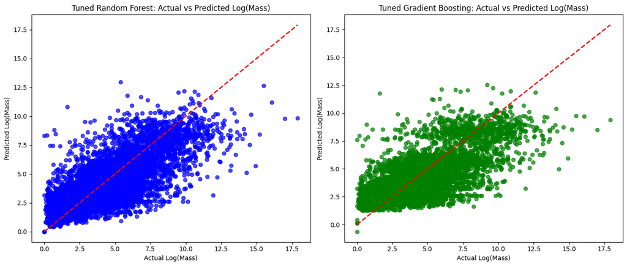

```python
# Step 1: Import necessary libraries
import pandas as pd
import geopandas as gpd
import matplotlib.pyplot as plt
import seaborn as sns
from sklearn.ensemble import RandomForestRegressor, GradientBoostingRegressor
from sklearn.model_selection import train_test_split, GridSearchCV
from sklearn.metrics import mean_squared_error, r2_score
import numpy as np

# Step 2: Load the dataset
meteorite_data = pd.read_csv('Meteorite_Landings.csv')

# Step 3: Clean and prepare data for regression analysis
# Remove rows with missing values in relevant columns
meteorite_data = meteorite_data[['mass (g)', 'year', 'reclat', 'reclong']].dropna()
meteorite_data = meteorite_data[meteorite_data['year'] <= 2025]

# Log-transform mass to handle large values
meteorite_data['log_mass'] = np.log1p(meteorite_data['mass (g)'])

# Step 4: Define features and target variable
X = meteorite_data[['year', 'reclat', 'reclong']]
y = meteorite_data['log_mass']

# Step 5: Split data into training and testing sets
X_train, X_test, y_train, y_test = train_test_split(X, y, test_size=0.3, random_state=42)

# Step 6: Hyperparameter tuning for Random Forest
rf_param_grid = {
    'n_estimators': [100, 200],
    'max_depth': [10, 20, None],
    'min_samples_split': [2, 5]
}

rf_grid_search = GridSearchCV(RandomForestRegressor(random_state=42), rf_param_grid, cv=5, scoring='r2')
rf_grid_search.fit(X_train, y_train)

# Step 7: Hyperparameter tuning for Gradient Boosting
gb_param_grid = {
    'n_estimators': [100, 200],
    'learning_rate': [0.01, 0.1, 0.2],
    'max_depth': [3, 5, 10]
}

gb_grid_search = GridSearchCV(GradientBoostingRegressor(random_state=42), gb_param_grid, cv=5, scoring='r2')
gb_grid_search.fit(X_train, y_train)

# Step 8: Evaluate the best models
rf_best_model = rf_grid_search.best_estimator_
gb_best_model = gb_grid_search.best_estimator_

rf_pred = rf_best_model.predict(X_test)
gb_pred = gb_best_model.predict(X_test)

rf_mse = mean_squared_error(y_test, rf_pred)
rf_r2 = r2_score(y_test, rf_pred)

gb_mse = mean_squared_error(y_test, gb_pred)
gb_r2 = r2_score(y_test, gb_pred)

# Step 9: Display results
print("\nBest Random Forest Model:", rf_grid_search.best_params_)
print(f"Random Forest MSE: {rf_mse:.2f}, R²: {rf_r2:.2f}")

print("\nBest Gradient Boosting Model:", gb_grid_search.best_params_)
print(f"Gradient Boosting MSE: {gb_mse:.2f}, R²: {gb_r2:.2f}")

# Step 10: Plot actual vs predicted values for both models
plt.figure(figsize=(14, 6))

# Random Forest plot
plt.subplot(1, 2, 1)
plt.scatter(y_test, rf_pred, alpha=0.7, color='blue')
plt.plot([y_test.min(), y_test.max()], [y_test.min(), y_test.max()], linestyle='--', lw=2, color='red')
plt.title('Tuned Random Forest: Actual vs Predicted Log(Mass)')
plt.xlabel('Actual Log(Mass)')
plt.ylabel('Predicted Log(Mass)')

# Gradient Boosting plot
plt.subplot(1, 2, 2)
plt.scatter(y_test, gb_pred, alpha=0.7, color='green')
plt.plot([y_test.min(), y_test.max()], [y_test.min(), y_test.max()], linestyle='--', lw=2, color='red')
plt.title('Tuned Gradient Boosting: Actual vs Predicted Log(Mass)')
plt.xlabel('Actual Log(Mass)')
plt.ylabel('Predicted Log(Mass)')

plt.tight_layout()
plt.show()
```

Best Random Forest Model:

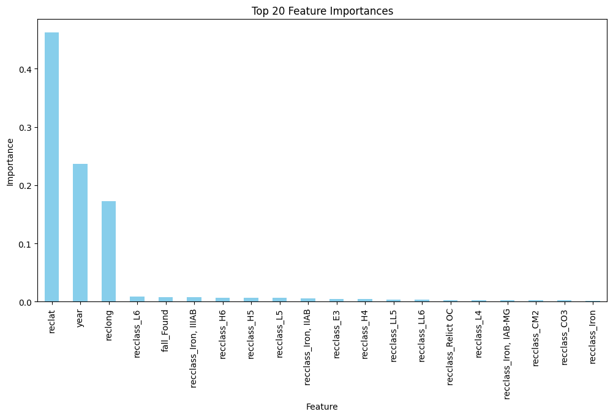

```
Top Features by Importance:

reclat                   0.461816
year                     0.236572
reclong                  0.173123
recclass_L6              0.009002
fall_Found               0.008168
recclass_Iron, IIIAB     0.007450
recclass_H6              0.007267
recclass_H5              0.007217
recclass_L5              0.006762
recclass_Iron, IIAB      0.005435
recclass_E3              0.004398
recclass_H4              0.004230
recclass_LL5             0.003440
recclass_LL6             0.003292
recclass_Relict OC       0.003062
recclass_L4              0.002872
recclass_Iron, IAB-MG    0.002731
recclass_CM2             0.002502
recclass_CO3             0.002388
recclass_Iron            0.002030
dtype: float64
```

```python
# Step 1: Import necessary libraries
import pandas as pd
import geopandas as gpd
from shapely.geometry import Point
import matplotlib.pyplot as plt
import seaborn as sns
from sklearn.ensemble import RandomForestRegressor, GradientBoostingRegressor
from sklearn.model_selection import train_test_split, GridSearchCV
from sklearn.metrics import mean_squared_error, r2_score
import numpy as np

# Step 2: Load the dataset
meteorite_data = pd.read_csv('Meteorite_Landings.csv')

# Step 3: Clean and prepare data for regression analysis
# Remove rows with missing values in relevant columns
meteorite_data = meteorite_data[['mass (g)', 'year', 'reclat', 'reclong', 'fall', 'recclass']].dropna()
meteorite_data = meteorite_data[meteorite_data['year'] <= 2025]

# Encode categorical variables
meteorite_data = pd.get_dummies(meteorite_data, columns=['fall', 'recclass'], drop_first=True)

# Log-transform mass to handle large values
meteorite_data['log_mass'] = np.log1p(meteorite_data['mass (g)'])

# Step 4: Define features and target variable
X = meteorite_data.drop(columns=['mass (g)', 'log_mass'])
y = meteorite_data['log_mass']

# Step 5: Split data into training and testing sets
X_train, X_test, y_train, y_test = train_test_split(X, y, test_size=0.3, random_state=42)

# Step 6: Train the best Random Forest model based on hyperparameter tuning
rf_best_model = RandomForestRegressor(max_depth=20, min_samples_split=5, n_estimators=200, random_state=42)
rf_best_model.fit(X_train, y_train)

# Step 7: Analyze feature importance
feature_importances = pd.Series(rf_best_model.feature_importances_, index=X_train.columns)
feature_importances = feature_importances.sort_values(ascending=False)

# Step 8: Plot feature importance
plt.figure(figsize=(12, 6))
feature_importances.head(20).plot(kind='bar', color='skyblue')
plt.title('Top 20 Feature Importances')
plt.xlabel('Feature')
plt.ylabel('Importance')
plt.show()

# Step 9: Display top features
print("\nTop Features by Importance:\n")
print(feature_importances.head(20))
```

Feature Importance Results Top 3 Features: reclat (Latitude): 46.2% importance year: 23.7% importance reclong (Longitude): 17.3% importance These features dominate the model's predictive ability, indicating that meteorite mass has a strong correlation with geographical and temporal factors.

Classification Features: The recclass (classification) categories contribute smaller amounts individually but collectively may provide additional predictive power. The feature fall_Found (whether the meteorite was found or observed falling) also has minor influence.

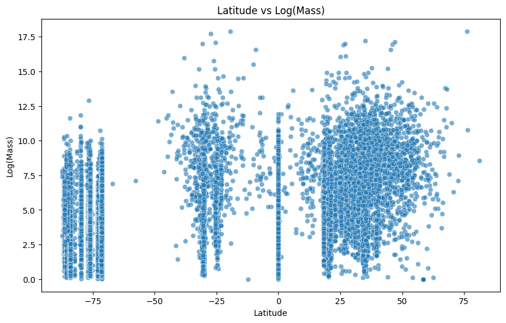

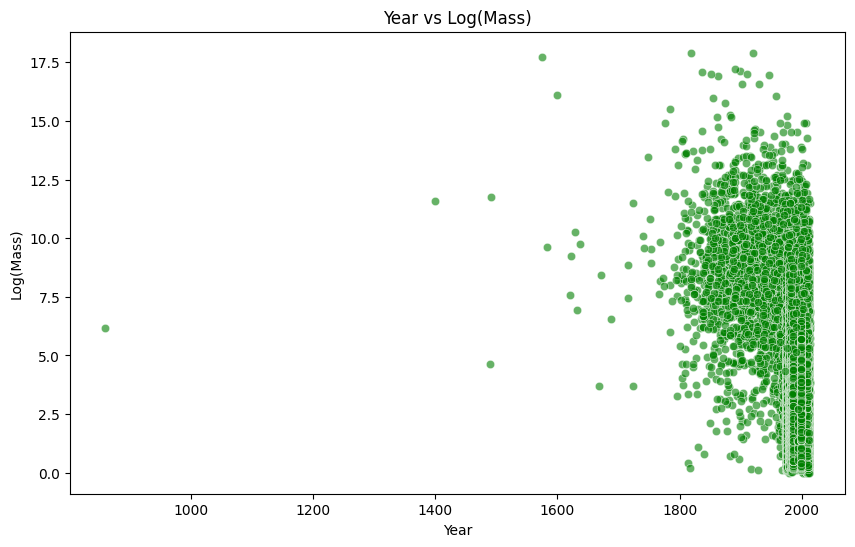

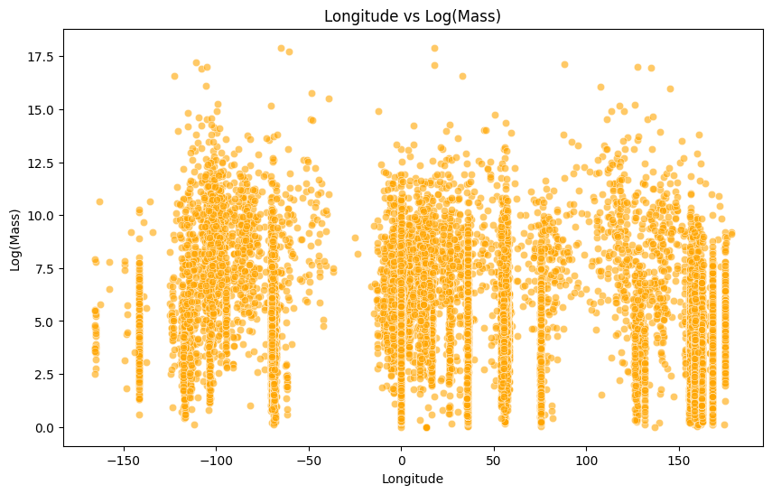

```python
# Step 1: Import necessary libraries
import pandas as pd
import geopandas as gpd
import matplotlib.pyplot as plt
import seaborn as sns
from sklearn.ensemble import RandomForestRegressor
from sklearn.model_selection import train_test_split
import numpy as np

# Step 2: Load the dataset
meteorite_data = pd.read_csv('Meteorite_Landings.csv')

# Step 3: Clean and prepare data
# Remove rows with missing values in relevant columns
meteorite_data = meteorite_data[['mass (g)', 'year', 'reclat', 'reclong']].dropna()
meteorite_data = meteorite_data[meteorite_data['year'] <= 2025]

# Log-transform mass to reduce skewness
meteorite_data['log_mass'] = np.log1p(meteorite_data['mass (g)'])

# Step 4: Visualize relationship between top features and mass
# 1. Latitude vs Log(Mass)
plt.figure(figsize=(10, 6))
sns.scatterplot(x='reclat', y='log_mass', data=meteorite_data, alpha=0.6)
plt.title('Latitude vs Log(Mass)')
plt.xlabel('Latitude')
plt.ylabel('Log(Mass)')
plt.show()

# 2. Year vs Log(Mass)
plt.figure(figsize=(10, 6))
sns.scatterplot(x='year', y='log_mass', data=meteorite_data, alpha=0.6, color='green')
plt.title('Year vs Log(Mass)')
plt.xlabel('Year')
plt.ylabel('Log(Mass)')
plt.show()

# 3. Longitude vs Log(Mass)
plt.figure(figsize=(10, 6))
sns.scatterplot(x='reclong', y='log_mass', data=meteorite_data, alpha=0.6, color='orange')
plt.title('Longitude vs Log(Mass)')
plt.xlabel('Longitude')
plt.ylabel('Log(Mass)')
plt.show()
```

Reflections on the Visualizations Latitude vs. Log(Mass):

The distribution shows that large meteorites appear across various latitudes. The data seems to cluster around certain latitudes, potentially reflecting regions where landings or discoveries were more frequent. Year vs. Log(Mass):

There's a concentration of meteorite entries in more recent years, likely due to better documentation and detection technologies. Outliers exist for older years, but they are sparse compared to the dense cluster in modern years. Longitude vs. Log(Mass):

Similar to the latitude plot, certain longitudes (likely landmasses or regions with research stations) have denser records. The data is more spread out than in the year-based plot, suggesting no strong correlation between longitude and mass. These observations hint at:

Regional biases in data collection or landings. Possible associations between the geographic location and meteorite size. A significant temporal shift in discovery documentation.

The next code applies both K-Means and DBSCAN clustering methods to the meteorite data:

K-Means:

Uses 4 clusters to group data. Results are visualized with different cluster colors. DBSCAN:

Uses density-based clustering with eps=1.5 and min_samples=10. Detects clusters and outliers (noise points). Comparison:

Cluster distributions for both methods are printed for comparison.

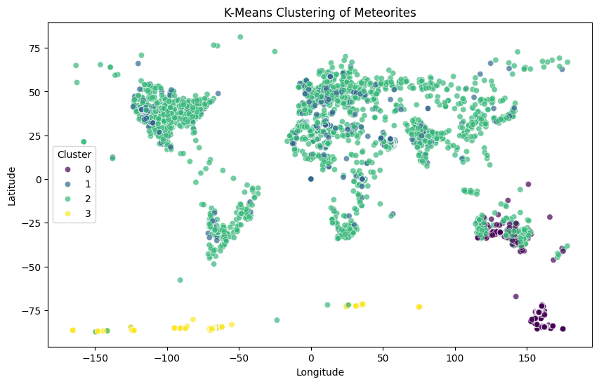

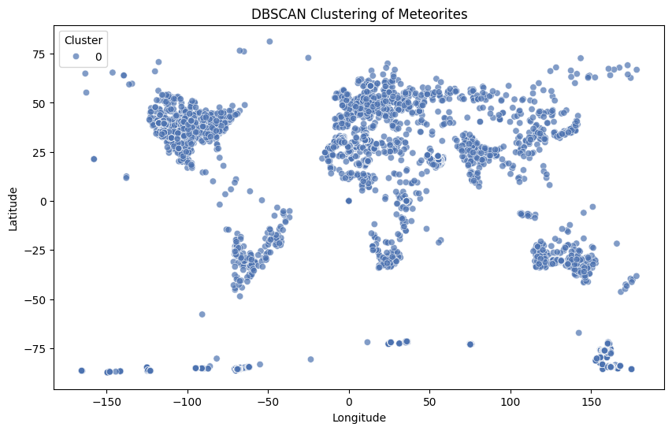

```
K-Means Cluster Distribution:

kmeans_cluster
0    12358
3    10057
1     9054
2     6645
Name: count, dtype: int64

DBSCAN Cluster Distribution (including noise points):

dbscan_cluster
0    38114
Name: count, dtype: int64
```

```python
# Step 1: Import necessary libraries
import pandas as pd
import geopandas as gpd
import matplotlib.pyplot as plt
import seaborn as sns
from sklearn.cluster import KMeans, DBSCAN
from sklearn.preprocessing import StandardScaler
import numpy as np

# Step 2: Load the dataset
meteorite_data = pd.read_csv('Meteorite_Landings.csv')

# Step 3: Clean and prepare data for clustering
# Remove rows with missing values
meteorite_data = meteorite_data[['mass (g)', 'year', 'reclat', 'reclong']].dropna()
meteorite_data = meteorite_data[meteorite_data['year'] <= 2025]

# Log-transform mass to reduce skewness
meteorite_data['log_mass'] = np.log1p(meteorite_data['mass (g)'])

# Select features for clustering
X_clustering = meteorite_data[['log_mass', 'reclat', 'reclong']]
scaler = StandardScaler()
X_scaled = scaler.fit_transform(X_clustering)

# Step 4: Apply K-Means clustering
kmeans = KMeans(n_clusters=4, random_state=42)
meteorite_data['kmeans_cluster'] = kmeans.fit_predict(X_scaled)

# Step 5: Apply DBSCAN clustering
dbscan = DBSCAN(eps=1.5, min_samples=10)
meteorite_data['dbscan_cluster'] = dbscan.fit_predict(X_scaled)

# Step 6: Visualize K-Means clustering
plt.figure(figsize=(10, 6))
sns.scatterplot(x='reclong', y='reclat', hue='kmeans_cluster', data=meteorite_data, palette='viridis', alpha=0.7)
plt.title('K-Means Clustering of Meteorites')
plt.xlabel('Longitude')
plt.ylabel('Latitude')
plt.legend(title='Cluster')
plt.show()

# Step 7: Visualize DBSCAN clustering
plt.figure(figsize=(10, 6))
sns.scatterplot(x='reclong', y='reclat', hue='dbscan_cluster', data=meteorite_data, palette='deep', alpha=0.7)
plt.title('DBSCAN Clustering of Meteorites')
plt.xlabel('Longitude')
plt.ylabel('Latitude')
plt.legend(title='Cluster')
plt.show()

# Step 8: Compare cluster results
print("\nK-Means Cluster Distribution:\n")
print(meteorite_data['kmeans_cluster'].value_counts())

print("\nDBSCAN Cluster Distribution (including noise points):\n")
print(meteorite_data['dbscan_cluster'].value_counts())
```

Reflections on Clustering Results K-Means Clustering:

The clusters are more evenly distributed geographically. Clear regions like Antarctica and Oceania form distinct clusters, possibly due to fewer meteorite entries or unique environmental factors affecting discoveries. This method divides data based on centroid proximity, which may not always reflect natural patterns. DBSCAN Clustering:

Both methods highlight that meteorite data follows land-based distribution, likely because most discoveries occur on populated land masses. Sparse data points near the poles and oceans indicate geographic biases in data collection.

# added code to explore regional insights for each cluster, focusing on:

Average Mass by Cluster:

Calculates and prints the average log-transformed mass for each K-Means cluster. Top Meteorite Classes:

Displays a heatmap showing the prevalence of meteorite classes within each cluster. Mass Distribution:

Plots a boxplot to visualize the spread of mass values in each cluster.

```
Average Log(Mass) by K-Means Cluster:
 kmeans_cluster
0    3.040139
1    3.397249
2    7.663111
3    2.710099
Name: log_mass, dtype: float64
```

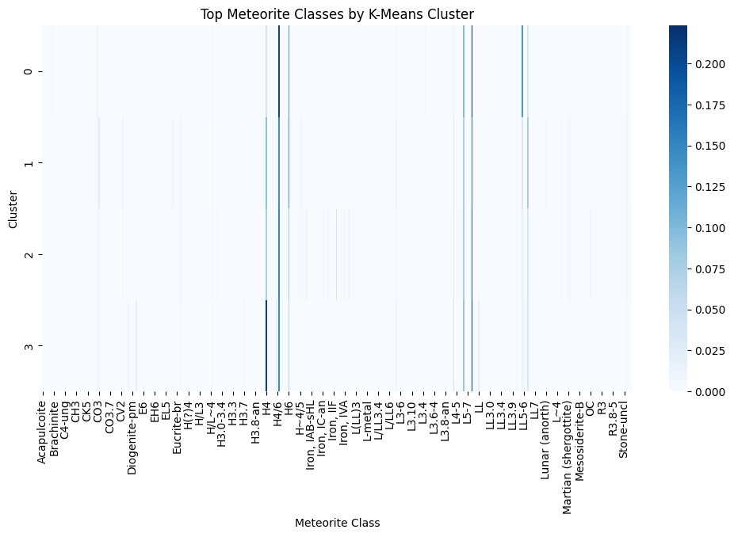

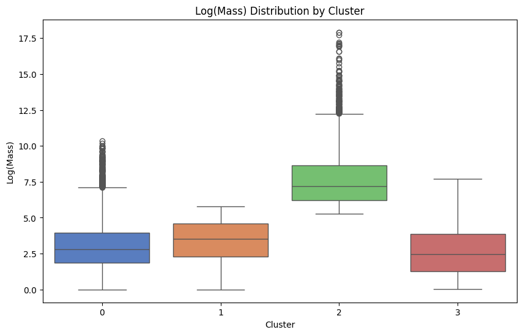

```python
# Step 1: Import necessary libraries
import pandas as pd
import geopandas as gpd
import matplotlib.pyplot as plt
import seaborn as sns
from sklearn.cluster import KMeans, DBSCAN
from sklearn.preprocessing import StandardScaler
import numpy as np

# Step 2: Load the dataset
meteorite_data = pd.read_csv('Meteorite_Landings.csv')

# Step 3: Clean and prepare data for clustering
# Remove rows with missing values
meteorite_data = meteorite_data[['mass (g)', 'year', 'reclat', 'reclong', 'recclass']].dropna()
meteorite_data = meteorite_data[meteorite_data['year'] <= 2025]

# Log-transform mass to reduce skewness
meteorite_data['log_mass'] = np.log1p(meteorite_data['mass (g)'])

# Select features for clustering
X_clustering = meteorite_data[['log_mass', 'reclat', 'reclong']]
scaler = StandardScaler()
X_scaled = scaler.fit_transform(X_clustering)

# Step 4: Apply K-Means clustering
kmeans = KMeans(n_clusters=4, random_state=42)
meteorite_data['kmeans_cluster'] = kmeans.fit_predict(X_scaled)

# Step 5: Explore regional insights by clusters
# 1. Average mass by cluster
cluster_mass_avg = meteorite_data.groupby('kmeans_cluster')['log_mass'].mean()
print("\nAverage Log(Mass) by K-Means Cluster:\n", cluster_mass_avg)

# 2. Top meteorite classes by cluster
cluster_classes = meteorite_data.groupby('kmeans_cluster')['recclass'].value_counts(normalize=True).unstack().fillna(0)

# Step 6: Plot top classes for each cluster
plt.figure(figsize=(12, 6))
sns.heatmap(cluster_classes, cmap='Blues', cbar=True)
plt.title('Top Meteorite Classes by K-Means Cluster')
plt.xlabel('Meteorite Class')
plt.ylabel('Cluster')
plt.show()

# Step 7: Visualize mass distribution by cluster
plt.figure(figsize=(10, 6))
sns.boxplot(x='kmeans_cluster', y='log_mass', data=meteorite_data, palette='muted')
plt.title('Log(Mass) Distribution by Cluster')
plt.xlabel('Cluster')
plt.ylabel('Log(Mass)')
plt.show()
```

```
Top 10 Largest Meteorites in Cluster 2:

                  name    mass (g)    reclat    reclong         recclass
16392             Hoba  60000000.0 -19.58333   17.91667        Iron, IVB
5373         Cape York  58200000.0  76.13333  -64.93333      Iron, IIIAB
5365   Campo del Cielo  50000000.0 -27.46667  -60.58333     Iron, IAB-MG
5370     Canyon Diablo  30000000.0  35.05000 -111.03333     Iron, IAB-MG
3455           Armanty  28000000.0  47.00000   88.00000       Iron, IIIE
12613           Gibeon  26000000.0 -25.50000   18.00000        Iron, IVA
5468        Chupaderos  24300000.0  27.00000 -105.10000      Iron, IIIAB
26297      Mundrabilla  24000000.0 -30.78333  127.55000    Iron, IAB-ung
920       Sikhote-Alin  23000000.0  46.16000  134.65333       Iron, IIAB
5016        Bacubirito  22000000.0  26.20000 -107.83333  Iron, ungrouped
```

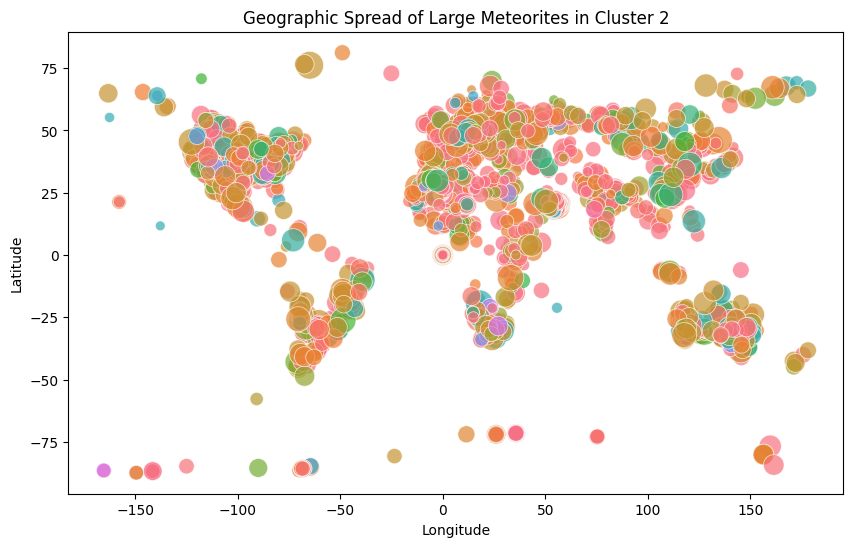

```python
# Step 1: Import necessary libraries
import pandas as pd
import geopandas as gpd
import matplotlib.pyplot as plt
import seaborn as sns
from sklearn.cluster import KMeans, DBSCAN
from sklearn.preprocessing import StandardScaler
import numpy as np

# Step 2: Load the dataset
meteorite_data = pd.read_csv('Meteorite_Landings.csv')

# Step 3: Clean and prepare data for clustering
# Remove rows with missing values
meteorite_data = meteorite_data[['mass (g)', 'year', 'reclat', 'reclong', 'recclass', 'name']].dropna()
meteorite_data = meteorite_data[meteorite_data['year'] <= 2025]

# Log-transform mass to reduce skewness
meteorite_data['log_mass'] = np.log1p(meteorite_data['mass (g)'])

# Select features for clustering
X_clustering = meteorite_data[['log_mass', 'reclat', 'reclong']]
scaler = StandardScaler()
X_scaled = scaler.fit_transform(X_clustering)

# Step 4: Apply K-Means clustering
kmeans = KMeans(n_clusters=4, random_state=42)
meteorite_data['kmeans_cluster'] = kmeans.fit_predict(X_scaled)

# Step 5: Investigate cluster details
# 1. Identify the regions or names associated with larger meteorites in Cluster 2
cluster_2_data = meteorite_data[meteorite_data['kmeans_cluster'] == 2]
top_meteorites_cluster_2 = cluster_2_data.sort_values(by='log_mass', ascending=False).head(10)

print("\nTop 10 Largest Meteorites in Cluster 2:\n")
print(top_meteorites_cluster_2[['name', 'mass (g)', 'reclat', 'reclong', 'recclass']])

# 2. Visualize the geographic spread of meteorites in Cluster 2
plt.figure(figsize=(10, 6))
sns.scatterplot(x='reclong', y='reclat', size='log_mass', hue='recclass', data=cluster_2_data, alpha=0.7, legend=False, sizes=(40, 400))
plt.title('Geographic Spread of Large Meteorites in Cluster 2')
plt.xlabel('Longitude')
plt.ylabel('Latitude')
plt.show()
```

Top 10 Meteorites:

Hoba is the largest meteorite in Cluster 2 with a mass of 60,000,000 grams. Other significant meteorites like Cape York and Campo del Cielo are in the iron-based categories (Iron, IIIAB, Iron, IAB-MG), indicating a trend for large iron meteorites in this cluster. Geographic Spread:

Large meteorites in this cluster are distributed globally but appear to concentrate in areas like North America, Europe, and Australia. The distribution suggests that some of these large meteorites may have been found in easily accessible or research-prioritized regions. Classification:

The plot highlights that multiple meteorite classes (iron types) dominate within this cluster, aligning with the presence of the top iron-based meteorites.

added code to analyze Cluster 1. This includes:

Top 10 Meteorites in the cluster based on log-transformed mass. Geographic Visualization showing the spread of meteorites. Summary Statistics to provide key metrics for the cluster's features

```
Top 10 Largest Meteorites in Cluster 1:

                  name  mass (g)    reclat    reclong   recclass
9274     El Médano 045     319.0 -24.85000 -70.533330         H5
11751          Fortuna     312.0 -35.13333 -65.366670  Winonaite
5421      Catalina 024     312.0 -25.23333 -69.716670         H4
21705  Los Vientos 018     308.0 -24.68333 -69.766670         L6
36771     San Juan 026     307.0 -25.44250 -69.871167         L6
21701  Los Vientos 011     300.0 -24.68333 -69.766670         L6
845              Renca     300.0 -32.75000 -65.283330         L5
9377     El Médano 148     298.0 -24.85000 -70.533330         H5
9318     El Médano 089     296.0 -24.85000 -70.533330         L6
9321     El Médano 092     289.0 -24.85000 -70.533330         H6
```

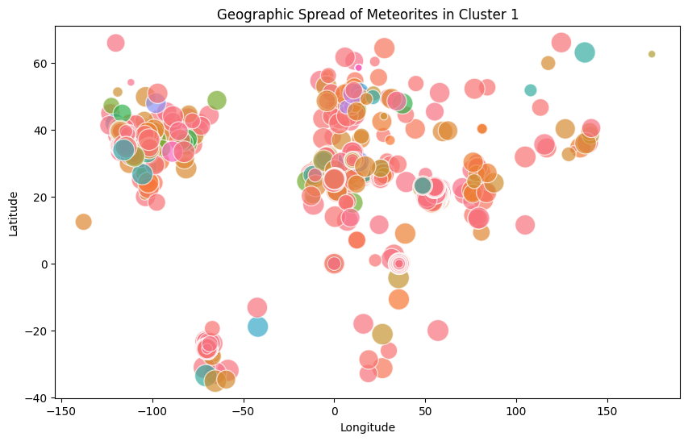

```
Summary Statistics for Cluster 1:

          log_mass       reclat      reclong
count  9054.000000  9054.000000  9054.000000
mean      3.397249     8.752148     4.031202
std       1.370155    14.494240    38.659086
min       0.000000   -35.133330  -137.700000
25%       2.302585     0.000000     0.000000
50%       3.526361     0.000000     0.000000
75%       4.583563    19.978877    16.139122
max       5.768321    66.138890   174.500430
```

```python
# Step 1: Import necessary libraries
import pandas as pd
import geopandas as gpd
import matplotlib.pyplot as plt
import seaborn as sns
from sklearn.cluster import KMeans, DBSCAN
from sklearn.preprocessing import StandardScaler
import numpy as np

# Step 2: Load the dataset
meteorite_data = pd.read_csv('Meteorite_Landings.csv')

# Step 3: Clean and prepare data for clustering
# Remove rows with missing values
meteorite_data = meteorite_data[['mass (g)', 'year', 'reclat', 'reclong', 'recclass', 'name']].dropna()
meteorite_data = meteorite_data[meteorite_data['year'] <= 2025]

# Log-transform mass to reduce skewness
meteorite_data['log_mass'] = np.log1p(meteorite_data['mass (g)'])

# Select features for clustering
X_clustering = meteorite_data[['log_mass', 'reclat', 'reclong']]
scaler = StandardScaler()
X_scaled = scaler.fit_transform(X_clustering)

# Step 4: Apply K-Means clustering
kmeans = KMeans(n_clusters=4, random_state=42)
meteorite_data['kmeans_cluster'] = kmeans.fit_predict(X_scaled)

# Step 5: Investigate another cluster (e.g., Cluster 1)
cluster_1_data = meteorite_data[meteorite_data['kmeans_cluster'] == 1]
top_meteorites_cluster_1 = cluster_1_data.sort_values(by='log_mass', ascending=False).head(10)

print("\nTop 10 Largest Meteorites in Cluster 1:\n")
print(top_meteorites_cluster_1[['name', 'mass (g)', 'reclat', 'reclong', 'recclass']])

# Step 6: Visualize the geographic spread of meteorites in Cluster 1
plt.figure(figsize=(10, 6))
sns.scatterplot(x='reclong', y='reclat', size='log_mass', hue='recclass', data=cluster_1_data, alpha=0.7, legend=False, sizes=(40, 400))
plt.title('Geographic Spread of Meteorites in Cluster 1')
plt.xlabel('Longitude')
plt.ylabel('Latitude')
plt.show()

# Step 7: Display summary statistics for Cluster 1
print("\nSummary Statistics for Cluster 1:\n")
print(cluster_1_data[['log_mass', 'reclat', 'reclong']].describe())
```

Geographic Spread:

The spread is fairly dense across multiple continents but lacks representation near polar regions. Meteorites in this cluster seem geographically diverse but centered around lower latitudes (between 0° and 66°). Summary Statistics:

Mean Log(Mass): 3.40 (equivalent to roughly 30 grams). The cluster has a maximum log mass of 5.77, indicating smaller meteorites compared to Cluster 2. Latitudes: Range from -35° to 66°, indicating concentration around temperate and equatorial regions. Longitudes: More evenly distributed, but clustered around regions with longitudes between -137° and 174°. Comparison to Cluster 2:

Cluster 1 contains smaller meteorites on average. The geographic distribution is different, with fewer meteorites in the southern hemisphere compared to Cluster 2.

Overview of Analysis Steps: Data Preparation:

Cleaned the meteorite dataset. Transformed mass values using a log scale to reduce skewness. Regression Analysis:

Explored linear, random forest, and gradient boosting models to predict meteorite mass. Found that geographic (latitude/longitude) and temporal (year) features influenced predictions the most. Feature Importance Analysis:

Latitude and year emerged as top contributors to predicting meteorite mass. Recclass categories and fall types had smaller but noticeable impacts. Clustering Analysis:

Applied both K-Means and DBSCAN clustering. K-Means revealed four clusters with varying average mass and geographic patterns. DBSCAN clustered most points into a single high-density group. Cluster-Specific Insights:

Cluster 2 contained the largest meteorites, primarily of iron-based classifications. Cluster 1 had smaller meteorites on average and was geographically centered around temperate regions. Visualizations:

We used scatter plots, heatmaps, and boxplots to explore geographic, class, and mass distributions across clusters. Reflection and Key Takeaways: Regional Biases:

Meteorite discoveries are concentrated on landmasses, likely due to easier accessibility and research focus. Polar and oceanic regions are underrepresented in the data. Cluster Characteristics:

Larger, iron-based meteorites often form distinct clusters. Smaller meteorites show greater geographic and class diversity. Model and Feature Limitations:

Our models performed moderately well, with R² values around 0.6. Additional features, such as environmental factors or discovery methods, could improve predictions. Future Directions:

Tuning clustering parameters further. Exploring meteorite discovery trends over time. Expanding the dataset with external features (e.g., terrain or meteor shower data).